# Risk Factor Analysis

## Outcome Variable

**Outcome Variable:** ever_stunted

## Predictor Variables

**Intervention Variable:** impsan

**Adjustment Set:**

unadjusted

## Stratifying Variables

The analysis was stratified on these variable(s):

- agecat
- studyid
- country

## Data Summary

| agecat | studyid | country | impsan | ever_stunted | n_cell | n |
| --- | --- | --- | --- | --- | --- | --- |
| 0-6 months | ki0047075b-MAL-ED | BANGLADESH | 0 | 0 | 33 | 242 |
| 0-6 months | ki0047075b-MAL-ED | BANGLADESH | 0 | 1 | 5 | 242 |
| 0-6 months | ki0047075b-MAL-ED | BANGLADESH | 1 | 0 | 170 | 242 |
| 0-6 months | ki0047075b-MAL-ED | BANGLADESH | 1 | 1 | 34 | 242 |
| 0-6 months | ki0047075b-MAL-ED | BRAZIL | 0 | 0 | 4 | 210 |
| 0-6 months | ki0047075b-MAL-ED | BRAZIL | 0 | 1 | 0 | 210 |
| 0-6 months | ki0047075b-MAL-ED | BRAZIL | 1 | 0 | 185 | 210 |
| 0-6 months | ki0047075b-MAL-ED | BRAZIL | 1 | 1 | 21 | 210 |
| 0-6 months | ki0047075b-MAL-ED | INDIA | 0 | 0 | 107 | 233 |
| 0-6 months | ki0047075b-MAL-ED | INDIA | 0 | 1 | 18 | 233 |
| 0-6 months | ki0047075b-MAL-ED | INDIA | 1 | 0 | 88 | 233 |
| 0-6 months | ki0047075b-MAL-ED | INDIA | 1 | 1 | 20 | 233 |
| 0-6 months | ki0047075b-MAL-ED | NEPAL | 0 | 0 | 1 | 236 |
| 0-6 months | ki0047075b-MAL-ED | NEPAL | 0 | 1 | 0 | 236 |
| 0-6 months | ki0047075b-MAL-ED | NEPAL | 1 | 0 | 208 | 236 |
| 0-6 months | ki0047075b-MAL-ED | NEPAL | 1 | 1 | 27 | 236 |
| 0-6 months | ki0047075b-MAL-ED | PERU | 0 | 0 | 174 | 263 |
| 0-6 months | ki0047075b-MAL-ED | PERU | 0 | 1 | 24 | 263 |
| 0-6 months | ki0047075b-MAL-ED | PERU | 1 | 0 | 57 | 263 |
| 0-6 months | ki0047075b-MAL-ED | PERU | 1 | 1 | 8 | 263 |
| 0-6 months | ki0047075b-MAL-ED | SOUTH AFRICA | 0 | 0 | 223 | 250 |
| 0-6 months | ki0047075b-MAL-ED | SOUTH AFRICA | 0 | 1 | 23 | 250 |
| 0-6 months | ki0047075b-MAL-ED | SOUTH AFRICA | 1 | 0 | 4 | 250 |
| 0-6 months | ki0047075b-MAL-ED | SOUTH AFRICA | 1 | 1 | 0 | 250 |
| 0-6 months | ki0047075b-MAL-ED | TANZANIA, UNITED REPUBLIC OF | 0 | 0 | 202 | 241 |
| 0-6 months | ki0047075b-MAL-ED | TANZANIA, UNITED REPUBLIC OF | 0 | 1 | 39 | 241 |
| 0-6 months | ki1017093-NIH-Birth | BANGLADESH | 0 | 0 | 327 | 629 |
| 0-6 months | ki1017093-NIH-Birth | BANGLADESH | 0 | 1 | 60 | 629 |
| 0-6 months | ki1017093-NIH-Birth | BANGLADESH | 1 | 0 | 203 | 629 |
| 0-6 months | ki1017093-NIH-Birth | BANGLADESH | 1 | 1 | 39 | 629 |

[output cut: 164 more lines]

The following strata were considered:

- agecat: 0-24 months, studyid: ki0047075b-MAL-ED, country: BANGLADESH
- agecat: 0-24 months, studyid: ki0047075b-MAL-ED, country: BRAZIL
- agecat: 0-24 months, studyid: ki0047075b-MAL-ED, country: INDIA
- agecat: 0-24 months, studyid: ki0047075b-MAL-ED, country: NEPAL
- agecat: 0-24 months, studyid: ki0047075b-MAL-ED, country: PERU
- agecat: 0-24 months, studyid: ki0047075b-MAL-ED, country: SOUTH AFRICA
- agecat: 0-24 months, studyid: ki0047075b-MAL-ED, country: TANZANIA, UNITED REPUBLIC OF
- agecat: 0-24 months, studyid: ki1017093-NIH-Birth, country: BANGLADESH
- agecat: 0-24 months, studyid: ki1017093b-PROVIDE, country: BANGLADESH
- agecat: 0-24 months, studyid: ki1017093c-NIH-Crypto, country: BANGLADESH
- agecat: 0-24 months, studyid: ki1114097-CONTENT, country: PERU
- agecat: 0-24 months, studyid: ki1135781-COHORTS, country: GUATEMALA
- agecat: 0-24 months, studyid: ki1135781-COHORTS, country: INDIA
- agecat: 0-24 months, studyid: ki1135781-COHORTS, country: PHILIPPINES
- agecat: 0-24 months, studyid: ki1148112-LCNI-5, country: MALAWI
- agecat: 0-24 months, studyid: kiGH5241-JiVitA-3, country: BANGLADESH
- agecat: 0-24 months, studyid: kiGH5241-JiVitA-4, country: BANGLADESH
- agecat: 0-6 months, studyid: ki0047075b-MAL-ED, country: BANGLADESH
- agecat: 0-6 months, studyid: ki0047075b-MAL-ED, country: BRAZIL
- agecat: 0-6 months, studyid: ki0047075b-MAL-ED, country: INDIA
- agecat: 0-6 months, studyid: ki0047075b-MAL-ED, country: NEPAL
- agecat: 0-6 months, studyid: ki0047075b-MAL-ED, country: PERU
- agecat: 0-6 months, studyid: ki0047075b-MAL-ED, country: SOUTH AFRICA
- agecat: 0-6 months, studyid: ki0047075b-MAL-ED, country: TANZANIA, UNITED REPUBLIC OF
- agecat: 0-6 months, studyid: ki1017093-NIH-Birth, country: BANGLADESH
- agecat: 0-6 months, studyid: ki1017093b-PROVIDE, country: BANGLADESH
- agecat: 0-6 months, studyid: ki1017093c-NIH-Crypto, country: BANGLADESH
- agecat: 0-6 months, studyid: ki1114097-CONTENT, country: PERU
- agecat: 0-6 months, studyid: ki1135781-COHORTS, country: GUATEMALA
- agecat: 0-6 months, studyid: ki1135781-COHORTS, country: INDIA
- agecat: 0-6 months, studyid: ki1135781-COHORTS, country: PHILIPPINES
- agecat: 0-6 months, studyid: ki1148112-LCNI-5, country: MALAWI
- agecat: 0-6 months, studyid: kiGH5241-JiVitA-3, country: BANGLADESH
- agecat: 0-6 months, studyid: kiGH5241-JiVitA-4, country: BANGLADESH
- agecat: 6-24 months, studyid: ki0047075b-MAL-ED, country: BANGLADESH
- agecat: 6-24 months, studyid: ki0047075b-MAL-ED, country: BRAZIL
- agecat: 6-24 months, studyid: ki0047075b-MAL-ED, country: INDIA
- agecat: 6-24 months, studyid: ki0047075b-MAL-ED, country: NEPAL
- agecat: 6-24 months, studyid: ki0047075b-MAL-ED, country: PERU
- agecat: 6-24 months, studyid: ki0047075b-MAL-ED, country: SOUTH AFRICA
- agecat: 6-24 months, studyid: ki0047075b-MAL-ED, country: TANZANIA, UNITED REPUBLIC OF
- agecat: 6-24 months, studyid: ki1017093-NIH-Birth, country: BANGLADESH
- agecat: 6-24 months, studyid: ki1017093b-PROVIDE, country: BANGLADESH
- agecat: 6-24 months, studyid: ki1017093c-NIH-Crypto, country: BANGLADESH
- agecat: 6-24 months, studyid: ki1114097-CONTENT, country: PERU
- agecat: 6-24 months, studyid: ki1135781-COHORTS, country: GUATEMALA
- agecat: 6-24 months, studyid: ki1135781-COHORTS, country: INDIA
- agecat: 6-24 months, studyid: ki1135781-COHORTS, country: PHILIPPINES
- agecat: 6-24 months, studyid: ki1148112-LCNI-5, country: MALAWI
- agecat: 6-24 months, studyid: kiGH5241-JiVitA-3, country: BANGLADESH
- agecat: 6-24 months, studyid: kiGH5241-JiVitA-4, country: BANGLADESH

## Methods Detail

We’re interested in the causal parameters $E[Y_a]$ for all values of $a \in \mathcal{A}$. These parameters represent the mean outcome if, possibly contrary to fact, we intervened to set all units to have $A=a$. Under the randomization and positivity assumptions, these are identified by the statistical parameters $\psi_a=E_W[E_{Y|A,W}(Y|A=a,W)]$. In addition, we’re interested in the mean of $Y$, $E[Y]$ under no intervention (the observed mean). We will estimate these parameters by using SuperLearner to fit the relevant likelihood factors – $E_{Y|A,W}(Y|A=a,W)$ and $p(A=a|W)$, and then updating our likelihood fit using a joint TMLE.

For unadjusted analyses ($W=\{\}$), initial likelihoods were estimated using Lrnr_glm to estimate the simple $E(Y|A)$ and Lrnr_mean to estimate $p(A)$. For adjusted analyses, a small library containing Lrnr_glmnet, Lrnr_xgboost, and Lrnr_mean was used.

Having estimated these parameters, we will then use the delta method to estimate relative risks and attributable risks relative to a prespecified baseline level of $A$.

[output not shown]

# Results Detail

## Results Plots

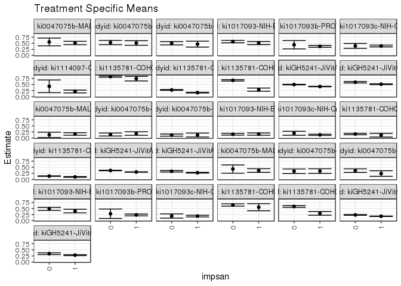

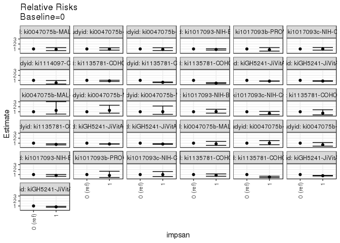

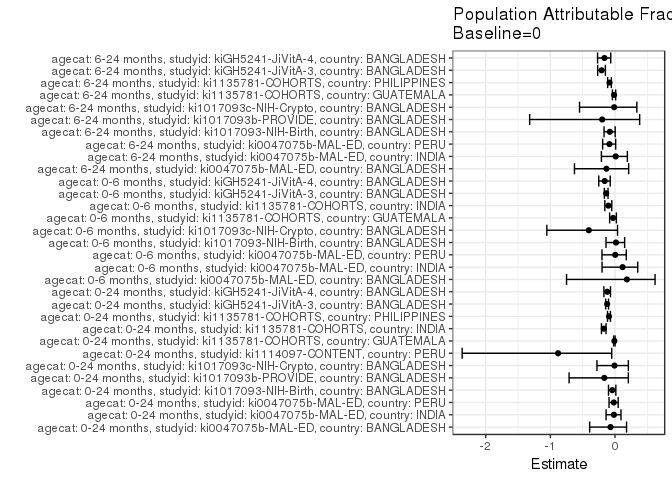

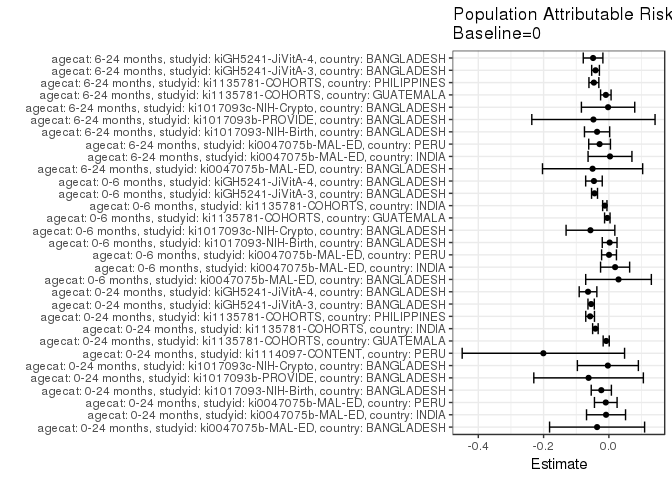

## Results Table

### Parameter: TSM

| agecat | studyid | country | intervention_level | baseline_level | estimate | ci_lower | ci_upper |
| --- | --- | --- | --- | --- | --- | --- | --- |
| 0-24 months | ki0047075b-MAL-ED | BANGLADESH | 0 | NA | 0.5526316 | 0.3942131 | 0.7110501 |
| 0-24 months | ki0047075b-MAL-ED | BANGLADESH | 1 | NA | 0.5098039 | 0.4410625 | 0.5785454 |
| 0-24 months | ki0047075b-MAL-ED | INDIA | 0 | NA | 0.5280000 | 0.4402969 | 0.6157031 |
| 0-24 months | ki0047075b-MAL-ED | INDIA | 1 | NA | 0.5092593 | 0.4147736 | 0.6037449 |
| 0-24 months | ki0047075b-MAL-ED | PERU | 0 | NA | 0.5000000 | 0.4302229 | 0.5697771 |
| 0-24 months | ki0047075b-MAL-ED | PERU | 1 | NA | 0.4615385 | 0.3401157 | 0.5829612 |
| 0-24 months | ki1017093-NIH-Birth | BANGLADESH | 0 | NA | 0.5684755 | 0.5190903 | 0.6178606 |
| 0-24 months | ki1017093-NIH-Birth | BANGLADESH | 1 | NA | 0.5082645 | 0.4452273 | 0.5713016 |
| 0-24 months | ki1017093b-PROVIDE | BANGLADESH | 0 | NA | 0.4375000 | 0.2654975 | 0.6095025 |
| 0-24 months | ki1017093b-PROVIDE | BANGLADESH | 1 | NA | 0.3723724 | 0.3356304 | 0.4091143 |
| 0-24 months | ki1017093c-NIH-Crypto | BANGLADESH | 0 | NA | 0.3913043 | 0.2915108 | 0.4910979 |
| 0-24 months | ki1017093c-NIH-Crypto | BANGLADESH | 1 | NA | 0.3877863 | 0.3504470 | 0.4251256 |
| 0-24 months | ki1114097-CONTENT | PERU | 0 | NA | 0.4285714 | 0.1687416 | 0.6884013 |
| 0-24 months | ki1114097-CONTENT | PERU | 1 | NA | 0.2139303 | 0.1571067 | 0.2707540 |
| 0-24 months | ki1135781-COHORTS | GUATEMALA | 0 | NA | 0.8314465 | 0.8054091 | 0.8574840 |
| 0-24 months | ki1135781-COHORTS | GUATEMALA | 1 | NA | 0.7439024 | 0.6493768 | 0.8384281 |
| 0-24 months | ki1135781-COHORTS | INDIA | 0 | NA | 0.2785863 | 0.2634423 | 0.2937302 |
| 0-24 months | ki1135781-COHORTS | INDIA | 1 | NA | 0.1682382 | 0.1519035 | 0.1845730 |
| 0-24 months | ki1135781-COHORTS | PHILIPPINES | 0 | NA | 0.6738916 | 0.6450398 | 0.7027434 |
| 0-24 months | ki1135781-COHORTS | PHILIPPINES | 1 | NA | 0.2905028 | 0.2239672 | 0.3570384 |
| 0-24 months | kiGH5241-JiVitA-3 | BANGLADESH | 0 | NA | 0.4982528 | 0.4863006 | 0.5102050 |
| 0-24 months | kiGH5241-JiVitA-3 | BANGLADESH | 1 | NA | 0.4200867 | 0.4114213 | 0.4287522 |
| 0-24 months | kiGH5241-JiVitA-4 | BANGLADESH | 0 | NA | 0.5961228 | 0.5650516 | 0.6271940 |
| 0-24 months | kiGH5241-JiVitA-4 | BANGLADESH | 1 | NA | 0.5133715 | 0.4952724 | 0.5314707 |
| 0-6 months | ki0047075b-MAL-ED | BANGLADESH | 0 | NA | 0.1315789 | 0.0238794 | 0.2392785 |
| 0-6 months | ki0047075b-MAL-ED | BANGLADESH | 1 | NA | 0.1666667 | 0.1154200 | 0.2179134 |
| 0-6 months | ki0047075b-MAL-ED | INDIA | 0 | NA | 0.1440000 | 0.0823199 | 0.2056801 |
| 0-6 months | ki0047075b-MAL-ED | INDIA | 1 | NA | 0.1851852 | 0.1117671 | 0.2586032 |
| 0-6 months | ki0047075b-MAL-ED | PERU | 0 | NA | 0.1212121 | 0.0756653 | 0.1667589 |
| 0-6 months | ki0047075b-MAL-ED | PERU | 1 | NA | 0.1230769 | 0.0430589 | 0.2030949 |
| 0-6 months | ki1017093-NIH-Birth | BANGLADESH | 0 | NA | 0.1550388 | 0.1189496 | 0.1911279 |
| 0-6 months | ki1017093-NIH-Birth | BANGLADESH | 1 | NA | 0.1611570 | 0.1147962 | 0.2075178 |
| 0-6 months | ki1017093c-NIH-Crypto | BANGLADESH | 0 | NA | 0.1956522 | 0.1145356 | 0.2767687 |
| 0-6 months | ki1017093c-NIH-Crypto | BANGLADESH | 1 | NA | 0.1312977 | 0.1054166 | 0.1571788 |
| 0-6 months | ki1135781-COHORTS | GUATEMALA | 0 | NA | 0.1652893 | 0.1356694 | 0.1949092 |
| 0-6 months | ki1135781-COHORTS | GUATEMALA | 1 | NA | 0.1176471 | 0.0410119 | 0.1942822 |
| 0-6 months | ki1135781-COHORTS | INDIA | 0 | NA | 0.1340049 | 0.1223385 | 0.1456713 |
| 0-6 months | ki1135781-COHORTS | INDIA | 1 | NA | 0.1002597 | 0.0868415 | 0.1136780 |
| 0-6 months | kiGH5241-JiVitA-3 | BANGLADESH | 0 | NA | 0.3659420 | 0.3547062 | 0.3771779 |
| 0-6 months | kiGH5241-JiVitA-3 | BANGLADESH | 1 | NA | 0.3027411 | 0.2949080 | 0.3105742 |
| 0-6 months | kiGH5241-JiVitA-4 | BANGLADESH | 0 | NA | 0.3321859 | 0.3024619 | 0.3619099 |
| 0-6 months | kiGH5241-JiVitA-4 | BANGLADESH | 1 | NA | 0.2730721 | 0.2578819 | 0.2882622 |
| 6-24 months | ki0047075b-MAL-ED | BANGLADESH | 0 | NA | 0.4242424 | 0.2551849 | 0.5932999 |
| 6-24 months | ki0047075b-MAL-ED | BANGLADESH | 1 | NA | 0.3641975 | 0.2899065 | 0.4384886 |
| 6-24 months | ki0047075b-MAL-ED | INDIA | 0 | NA | 0.3333333 | 0.2387893 | 0.4278774 |
| 6-24 months | ki0047075b-MAL-ED | INDIA | 1 | NA | 0.3402062 | 0.2456771 | 0.4347353 |
| 6-24 months | ki0047075b-MAL-ED | PERU | 0 | NA | 0.3588235 | 0.2865591 | 0.4310879 |
| 6-24 months | ki0047075b-MAL-ED | PERU | 1 | NA | 0.2407407 | 0.1264548 | 0.3550266 |
| 6-24 months | ki1017093-NIH-Birth | BANGLADESH | 0 | NA | 0.4861660 | 0.4245052 | 0.5478268 |
| 6-24 months | ki1017093-NIH-Birth | BANGLADESH | 1 | NA | 0.3952096 | 0.3209720 | 0.4694471 |
| 6-24 months | ki1017093b-PROVIDE | BANGLADESH | 0 | NA | 0.2857143 | 0.0923040 | 0.4791246 |
| 6-24 months | ki1017093b-PROVIDE | BANGLADESH | 1 | NA | 0.2362869 | 0.1980059 | 0.2745679 |
| 6-24 months | ki1017093c-NIH-Crypto | BANGLADESH | 0 | NA | 0.1923077 | 0.1047735 | 0.2798419 |
| 6-24 months | ki1017093c-NIH-Crypto | BANGLADESH | 1 | NA | 0.1894934 | 0.1561956 | 0.2227912 |
| 6-24 months | ki1135781-COHORTS | GUATEMALA | 0 | NA | 0.6452442 | 0.5976449 | 0.6928436 |
| 6-24 months | ki1135781-COHORTS | GUATEMALA | 1 | NA | 0.5555556 | 0.4102055 | 0.7009056 |
| 6-24 months | ki1135781-COHORTS | PHILIPPINES | 0 | NA | 0.5854993 | 0.5497667 | 0.6212319 |
| 6-24 months | ki1135781-COHORTS | PHILIPPINES | 1 | NA | 0.3000000 | 0.2240473 | 0.3759527 |
| 6-24 months | kiGH5241-JiVitA-3 | BANGLADESH | 0 | NA | 0.2378929 | 0.2228463 | 0.2529396 |
| 6-24 months | kiGH5241-JiVitA-3 | BANGLADESH | 1 | NA | 0.1823023 | 0.1737471 | 0.1908576 |
| 6-24 months | kiGH5241-JiVitA-4 | BANGLADESH | 0 | NA | 0.3437838 | 0.3088665 | 0.3787011 |
| 6-24 months | kiGH5241-JiVitA-4 | BANGLADESH | 1 | NA | 0.2821650 | 0.2643093 | 0.3000208 |

### Parameter: E(Y)

| agecat | studyid | country | intervention_level | baseline_level | estimate | ci_lower | ci_upper |
| --- | --- | --- | --- | --- | --- | --- | --- |
| 0-24 months | ki0047075b-MAL-ED | BANGLADESH | NA | NA | 0.5165289 | 0.4534372 | 0.5796206 |
| 0-24 months | ki0047075b-MAL-ED | INDIA | NA | NA | 0.5193133 | 0.4550224 | 0.5836043 |
| 0-24 months | ki0047075b-MAL-ED | PERU | NA | NA | 0.4904943 | 0.4299617 | 0.5510268 |
| 0-24 months | ki1017093-NIH-Birth | BANGLADESH | NA | NA | 0.5453100 | 0.5063654 | 0.5842547 |
| 0-24 months | ki1017093b-PROVIDE | BANGLADESH | NA | NA | 0.3753582 | 0.3394105 | 0.4113058 |
| 0-24 months | ki1017093c-NIH-Crypto | BANGLADESH | NA | NA | 0.3882195 | 0.3532480 | 0.4231911 |
| 0-24 months | ki1114097-CONTENT | PERU | NA | NA | 0.2279070 | 0.1717046 | 0.2841094 |
| 0-24 months | ki1135781-COHORTS | GUATEMALA | NA | NA | 0.8232611 | 0.7980013 | 0.8485210 |
| 0-24 months | ki1135781-COHORTS | INDIA | NA | NA | 0.2372724 | 0.2259059 | 0.2486388 |
| 0-24 months | ki1135781-COHORTS | PHILIPPINES | NA | NA | 0.6164154 | 0.5888226 | 0.6440082 |
| 0-24 months | kiGH5241-JiVitA-3 | BANGLADESH | NA | NA | 0.4439299 | 0.4364087 | 0.4514510 |
| 0-24 months | kiGH5241-JiVitA-4 | BANGLADESH | NA | NA | 0.5322521 | 0.5160648 | 0.5484394 |
| 0-6 months | ki0047075b-MAL-ED | BANGLADESH | NA | NA | 0.1611570 | 0.1147371 | 0.2075770 |
| 0-6 months | ki0047075b-MAL-ED | INDIA | NA | NA | 0.1630901 | 0.1155503 | 0.2106299 |
| 0-6 months | ki0047075b-MAL-ED | PERU | NA | NA | 0.1216730 | 0.0820887 | 0.1612573 |
| 0-6 months | ki1017093-NIH-Birth | BANGLADESH | NA | NA | 0.1573927 | 0.1289105 | 0.1858749 |
| 0-6 months | ki1017093c-NIH-Crypto | BANGLADESH | NA | NA | 0.1392236 | 0.1143819 | 0.1640652 |
| 0-6 months | ki1135781-COHORTS | GUATEMALA | NA | NA | 0.1604755 | 0.1327241 | 0.1882269 |
| 0-6 months | ki1135781-COHORTS | INDIA | NA | NA | 0.1215151 | 0.1126348 | 0.1303954 |
| 0-6 months | kiGH5241-JiVitA-3 | BANGLADESH | NA | NA | 0.3220220 | 0.3152589 | 0.3287851 |
| 0-6 months | kiGH5241-JiVitA-4 | BANGLADESH | NA | NA | 0.2864960 | 0.2726657 | 0.3003263 |
| 6-24 months | ki0047075b-MAL-ED | BANGLADESH | NA | NA | 0.3743590 | 0.3062579 | 0.4424600 |
| 6-24 months | ki0047075b-MAL-ED | INDIA | NA | NA | 0.3367876 | 0.2699375 | 0.4036376 |
| 6-24 months | ki0047075b-MAL-ED | PERU | NA | NA | 0.3303571 | 0.2686253 | 0.3920890 |
| 6-24 months | ki1017093-NIH-Birth | BANGLADESH | NA | NA | 0.4500000 | 0.4023647 | 0.4976353 |
| 6-24 months | ki1017093b-PROVIDE | BANGLADESH | NA | NA | 0.2383838 | 0.2008095 | 0.2759582 |
| 6-24 months | ki1017093c-NIH-Crypto | BANGLADESH | NA | NA | 0.1898527 | 0.1587303 | 0.2209751 |
| 6-24 months | ki1135781-COHORTS | GUATEMALA | NA | NA | 0.6359447 | 0.5906239 | 0.6812655 |
| 6-24 months | ki1135781-COHORTS | PHILIPPINES | NA | NA | 0.5396096 | 0.5064896 | 0.5727297 |
| 6-24 months | kiGH5241-JiVitA-3 | BANGLADESH | NA | NA | 0.1970666 | 0.1890031 | 0.2051301 |
| 6-24 months | kiGH5241-JiVitA-4 | BANGLADESH | NA | NA | 0.2954018 | 0.2790421 | 0.3117615 |

### Parameter: RR

| agecat | studyid | country | intervention_level | baseline_level | estimate | ci_lower | ci_upper |
| --- | --- | --- | --- | --- | --- | --- | --- |
| 0-24 months | ki0047075b-MAL-ED | BANGLADESH | 0 | 0 | 1.0000000 | 1.0000000 | 1.0000000 |
| 0-24 months | ki0047075b-MAL-ED | BANGLADESH | 1 | 0 | 0.9225023 | 0.6720271 | 1.2663337 |
| 0-24 months | ki0047075b-MAL-ED | INDIA | 0 | 0 | 1.0000000 | 1.0000000 | 1.0000000 |
| 0-24 months | ki0047075b-MAL-ED | INDIA | 1 | 0 | 0.9645062 | 0.7518900 | 1.2372450 |
| 0-24 months | ki0047075b-MAL-ED | PERU | 0 | 0 | 1.0000000 | 1.0000000 | 1.0000000 |
| 0-24 months | ki0047075b-MAL-ED | PERU | 1 | 0 | 0.9230769 | 0.6853349 | 1.2432914 |
| 0-24 months | ki1017093-NIH-Birth | BANGLADESH | 0 | 0 | 1.0000000 | 1.0000000 | 1.0000000 |
| 0-24 months | ki1017093-NIH-Birth | BANGLADESH | 1 | 0 | 0.8940834 | 0.7684504 | 1.0402560 |
| 0-24 months | ki1017093b-PROVIDE | BANGLADESH | 0 | 0 | 1.0000000 | 1.0000000 | 1.0000000 |
| 0-24 months | ki1017093b-PROVIDE | BANGLADESH | 1 | 0 | 0.8511369 | 0.5674949 | 1.2765471 |
| 0-24 months | ki1017093c-NIH-Crypto | BANGLADESH | 0 | 0 | 1.0000000 | 1.0000000 | 1.0000000 |
| 0-24 months | ki1017093c-NIH-Crypto | BANGLADESH | 1 | 0 | 0.9910093 | 0.7545519 | 1.3015666 |
| 0-24 months | ki1114097-CONTENT | PERU | 0 | 0 | 1.0000000 | 1.0000000 | 1.0000000 |
| 0-24 months | ki1114097-CONTENT | PERU | 1 | 0 | 0.4991708 | 0.2575066 | 0.9676314 |
| 0-24 months | ki1135781-COHORTS | GUATEMALA | 0 | 0 | 1.0000000 | 1.0000000 | 1.0000000 |
| 0-24 months | ki1135781-COHORTS | GUATEMALA | 1 | 0 | 0.8947087 | 0.7849570 | 1.0198058 |
| 0-24 months | ki1135781-COHORTS | INDIA | 0 | 0 | 1.0000000 | 1.0000000 | 1.0000000 |
| 0-24 months | ki1135781-COHORTS | INDIA | 1 | 0 | 0.6038999 | 0.5403049 | 0.6749800 |
| 0-24 months | ki1135781-COHORTS | PHILIPPINES | 0 | 0 | 1.0000000 | 1.0000000 | 1.0000000 |
| 0-24 months | ki1135781-COHORTS | PHILIPPINES | 1 | 0 | 0.4310824 | 0.3414823 | 0.5441921 |
| 0-24 months | kiGH5241-JiVitA-3 | BANGLADESH | 0 | 0 | 1.0000000 | 1.0000000 | 1.0000000 |
| 0-24 months | kiGH5241-JiVitA-3 | BANGLADESH | 1 | 0 | 0.8431197 | 0.8183683 | 0.8686196 |
| 0-24 months | kiGH5241-JiVitA-4 | BANGLADESH | 0 | 0 | 1.0000000 | 1.0000000 | 1.0000000 |
| 0-24 months | kiGH5241-JiVitA-4 | BANGLADESH | 1 | 0 | 0.8611842 | 0.8103244 | 0.9152362 |
| 0-6 months | ki0047075b-MAL-ED | BANGLADESH | 0 | 0 | 1.0000000 | 1.0000000 | 1.0000000 |
| 0-6 months | ki0047075b-MAL-ED | BANGLADESH | 1 | 0 | 1.2666667 | 0.5283609 | 3.0366450 |
| 0-6 months | ki0047075b-MAL-ED | INDIA | 0 | 0 | 1.0000000 | 1.0000000 | 1.0000000 |
| 0-6 months | ki0047075b-MAL-ED | INDIA | 1 | 0 | 1.2860082 | 0.7174098 | 2.3052615 |
| 0-6 months | ki0047075b-MAL-ED | PERU | 0 | 0 | 1.0000000 | 1.0000000 | 1.0000000 |
| 0-6 months | ki0047075b-MAL-ED | PERU | 1 | 0 | 1.0153846 | 0.4791909 | 2.1515559 |
| 0-6 months | ki1017093-NIH-Birth | BANGLADESH | 0 | 0 | 1.0000000 | 1.0000000 | 1.0000000 |
| 0-6 months | ki1017093-NIH-Birth | BANGLADESH | 1 | 0 | 1.0394628 | 0.7179529 | 1.5049495 |
| 0-6 months | ki1017093c-NIH-Crypto | BANGLADESH | 0 | 0 | 1.0000000 | 1.0000000 | 1.0000000 |
| 0-6 months | ki1017093c-NIH-Crypto | BANGLADESH | 1 | 0 | 0.6710772 | 0.4240344 | 1.0620472 |
| 0-6 months | ki1135781-COHORTS | GUATEMALA | 0 | 0 | 1.0000000 | 1.0000000 | 1.0000000 |
| 0-6 months | ki1135781-COHORTS | GUATEMALA | 1 | 0 | 0.7117647 | 0.3621827 | 1.3987665 |
| 0-6 months | ki1135781-COHORTS | INDIA | 0 | 0 | 1.0000000 | 1.0000000 | 1.0000000 |
| 0-6 months | ki1135781-COHORTS | INDIA | 1 | 0 | 0.7481798 | 0.6377739 | 0.8776981 |
| 0-6 months | kiGH5241-JiVitA-3 | BANGLADESH | 0 | 0 | 1.0000000 | 1.0000000 | 1.0000000 |
| 0-6 months | kiGH5241-JiVitA-3 | BANGLADESH | 1 | 0 | 0.8272925 | 0.7962406 | 0.8595554 |
| 0-6 months | kiGH5241-JiVitA-4 | BANGLADESH | 0 | 0 | 1.0000000 | 1.0000000 | 1.0000000 |
| 0-6 months | kiGH5241-JiVitA-4 | BANGLADESH | 1 | 0 | 0.8220459 | 0.7412301 | 0.9116731 |
| 6-24 months | ki0047075b-MAL-ED | BANGLADESH | 0 | 0 | 1.0000000 | 1.0000000 | 1.0000000 |
| 6-24 months | ki0047075b-MAL-ED | BANGLADESH | 1 | 0 | 0.8584656 | 0.5486599 | 1.3432059 |
| 6-24 months | ki0047075b-MAL-ED | INDIA | 0 | 0 | 1.0000000 | 1.0000000 | 1.0000000 |
| 6-24 months | ki0047075b-MAL-ED | INDIA | 1 | 0 | 1.0206186 | 0.6861591 | 1.5181061 |
| 6-24 months | ki0047075b-MAL-ED | PERU | 0 | 0 | 1.0000000 | 1.0000000 | 1.0000000 |
| 6-24 months | ki0047075b-MAL-ED | PERU | 1 | 0 | 0.6709168 | 0.4006015 | 1.1236338 |
| 6-24 months | ki1017093-NIH-Birth | BANGLADESH | 0 | 0 | 1.0000000 | 1.0000000 | 1.0000000 |
| 6-24 months | ki1017093-NIH-Birth | BANGLADESH | 1 | 0 | 0.8129108 | 0.6480508 | 1.0197100 |
| 6-24 months | ki1017093b-PROVIDE | BANGLADESH | 0 | 0 | 1.0000000 | 1.0000000 | 1.0000000 |
| 6-24 months | ki1017093b-PROVIDE | BANGLADESH | 1 | 0 | 0.8270042 | 0.4123023 | 1.6588216 |
| 6-24 months | ki1017093c-NIH-Crypto | BANGLADESH | 0 | 0 | 1.0000000 | 1.0000000 | 1.0000000 |
| 6-24 months | ki1017093c-NIH-Crypto | BANGLADESH | 1 | 0 | 0.9853659 | 0.6049190 | 1.6050841 |
| 6-24 months | ki1135781-COHORTS | GUATEMALA | 0 | 0 | 1.0000000 | 1.0000000 | 1.0000000 |
| 6-24 months | ki1135781-COHORTS | GUATEMALA | 1 | 0 | 0.8610004 | 0.6560675 | 1.1299474 |
| 6-24 months | ki1135781-COHORTS | PHILIPPINES | 0 | 0 | 1.0000000 | 1.0000000 | 1.0000000 |
| 6-24 months | ki1135781-COHORTS | PHILIPPINES | 1 | 0 | 0.5123832 | 0.3949050 | 0.6648093 |
| 6-24 months | kiGH5241-JiVitA-3 | BANGLADESH | 0 | 0 | 1.0000000 | 1.0000000 | 1.0000000 |
| 6-24 months | kiGH5241-JiVitA-3 | BANGLADESH | 1 | 0 | 0.7663209 | 0.7127819 | 0.8238814 |
| 6-24 months | kiGH5241-JiVitA-4 | BANGLADESH | 0 | 0 | 1.0000000 | 1.0000000 | 1.0000000 |
| 6-24 months | kiGH5241-JiVitA-4 | BANGLADESH | 1 | 0 | 0.8207631 | 0.7304608 | 0.9222289 |

### Parameter: PAR

| agecat | studyid | country | intervention_level | baseline_level | estimate | ci_lower | ci_upper |
| --- | --- | --- | --- | --- | --- | --- | --- |
| 0-24 months | ki0047075b-MAL-ED | BANGLADESH | 0 | NA | -0.0361027 | -0.1816893 | 0.1094840 |
| 0-24 months | ki0047075b-MAL-ED | INDIA | 0 | NA | -0.0086867 | -0.0684539 | 0.0510805 |
| 0-24 months | ki0047075b-MAL-ED | PERU | 0 | NA | -0.0095057 | -0.0441756 | 0.0251642 |
| 0-24 months | ki1017093-NIH-Birth | BANGLADESH | 0 | NA | -0.0231654 | -0.0540598 | 0.0077289 |
| 0-24 months | ki1017093b-PROVIDE | BANGLADESH | 0 | NA | -0.0621418 | -0.2299645 | 0.1056808 |
| 0-24 months | ki1017093c-NIH-Crypto | BANGLADESH | 0 | NA | -0.0030848 | -0.0965125 | 0.0903429 |
| 0-24 months | ki1114097-CONTENT | PERU | 0 | NA | -0.2006645 | -0.4494174 | 0.0480885 |
| 0-24 months | ki1135781-COHORTS | GUATEMALA | 0 | NA | -0.0081854 | -0.0175069 | 0.0011360 |
| 0-24 months | ki1135781-COHORTS | INDIA | 0 | NA | -0.0413139 | -0.0497747 | -0.0328531 |
| 0-24 months | ki1135781-COHORTS | PHILIPPINES | 0 | NA | -0.0574762 | -0.0708374 | -0.0441150 |
| 0-24 months | kiGH5241-JiVitA-3 | BANGLADESH | 0 | NA | -0.0543229 | -0.0640430 | -0.0446028 |
| 0-24 months | kiGH5241-JiVitA-4 | BANGLADESH | 0 | NA | -0.0638707 | -0.0909182 | -0.0368231 |
| 0-6 months | ki0047075b-MAL-ED | BANGLADESH | 0 | NA | 0.0295781 | -0.0709768 | 0.1301329 |
| 0-6 months | ki0047075b-MAL-ED | INDIA | 0 | NA | 0.0190901 | -0.0254346 | 0.0636149 |
| 0-6 months | ki0047075b-MAL-ED | PERU | 0 | NA | 0.0004609 | -0.0222949 | 0.0232167 |
| 0-6 months | ki1017093-NIH-Birth | BANGLADESH | 0 | NA | 0.0023539 | -0.0202512 | 0.0249591 |
| 0-6 months | ki1017093c-NIH-Crypto | BANGLADESH | 0 | NA | -0.0564286 | -0.1311029 | 0.0182457 |
| 0-6 months | ki1135781-COHORTS | GUATEMALA | 0 | NA | -0.0048138 | -0.0131859 | 0.0035584 |
| 0-6 months | ki1135781-COHORTS | INDIA | 0 | NA | -0.0124898 | -0.0190857 | -0.0058939 |
| 0-6 months | kiGH5241-JiVitA-3 | BANGLADESH | 0 | NA | -0.0439200 | -0.0530279 | -0.0348121 |
| 0-6 months | kiGH5241-JiVitA-4 | BANGLADESH | 0 | NA | -0.0456899 | -0.0710945 | -0.0202853 |
| 6-24 months | ki0047075b-MAL-ED | BANGLADESH | 0 | NA | -0.0498834 | -0.2033266 | 0.1035597 |
| 6-24 months | ki0047075b-MAL-ED | INDIA | 0 | NA | 0.0034542 | -0.0637413 | 0.0706498 |
| 6-24 months | ki0047075b-MAL-ED | PERU | 0 | NA | -0.0284664 | -0.0617304 | 0.0047976 |
| 6-24 months | ki1017093-NIH-Birth | BANGLADESH | 0 | NA | -0.0361660 | -0.0747743 | 0.0024423 |
| 6-24 months | ki1017093b-PROVIDE | BANGLADESH | 0 | NA | -0.0473304 | -0.2361303 | 0.1414694 |
| 6-24 months | ki1017093c-NIH-Crypto | BANGLADESH | 0 | NA | -0.0024550 | -0.0841528 | 0.0792428 |
| 6-24 months | ki1135781-COHORTS | GUATEMALA | 0 | NA | -0.0092995 | -0.0253657 | 0.0067666 |
| 6-24 months | ki1135781-COHORTS | PHILIPPINES | 0 | NA | -0.0458897 | -0.0610745 | -0.0307048 |
| 6-24 months | kiGH5241-JiVitA-3 | BANGLADESH | 0 | NA | -0.0408264 | -0.0526449 | -0.0290078 |
| 6-24 months | kiGH5241-JiVitA-4 | BANGLADESH | 0 | NA | -0.0483820 | -0.0784608 | -0.0183033 |

### Parameter: PAF

| agecat | studyid | country | intervention_level | baseline_level | estimate | ci_lower | ci_upper |
| --- | --- | --- | --- | --- | --- | --- | --- |
| 0-24 months | ki0047075b-MAL-ED | BANGLADESH | 0 | NA | -0.0698947 | -0.3925800 | 0.1780187 |
| 0-24 months | ki0047075b-MAL-ED | INDIA | 0 | NA | -0.0167273 | -0.1386078 | 0.0921068 |
| 0-24 months | ki0047075b-MAL-ED | PERU | 0 | NA | -0.0193798 | -0.0926134 | 0.0489451 |
| 0-24 months | ki1017093-NIH-Birth | BANGLADESH | 0 | NA | -0.0424812 | -0.1008321 | 0.0127767 |
| 0-24 months | ki1017093b-PROVIDE | BANGLADESH | 0 | NA | -0.1655534 | -0.7106737 | 0.2058598 |
| 0-24 months | ki1017093c-NIH-Crypto | BANGLADESH | 0 | NA | -0.0079460 | -0.2797627 | 0.2061378 |
| 0-24 months | ki1114097-CONTENT | PERU | 0 | NA | -0.8804665 | -2.3642572 | -0.0510951 |
| 0-24 months | ki1135781-COHORTS | GUATEMALA | 0 | NA | -0.0099427 | -0.0213639 | 0.0013508 |
| 0-24 months | ki1135781-COHORTS | INDIA | 0 | NA | -0.1741201 | -0.2100535 | -0.1392537 |
| 0-24 months | ki1135781-COHORTS | PHILIPPINES | 0 | NA | -0.0932427 | -0.1161425 | -0.0708126 |
| 0-24 months | kiGH5241-JiVitA-3 | BANGLADESH | 0 | NA | -0.1223683 | -0.1446963 | -0.1004758 |
| 0-24 months | kiGH5241-JiVitA-4 | BANGLADESH | 0 | NA | -0.1200008 | -0.1722478 | -0.0700824 |
| 0-6 months | ki0047075b-MAL-ED | BANGLADESH | 0 | NA | 0.1835358 | -0.7499022 | 0.6190565 |
| 0-6 months | ki0047075b-MAL-ED | INDIA | 0 | NA | 0.1170526 | -0.2009612 | 0.3508566 |
| 0-6 months | ki0047075b-MAL-ED | PERU | 0 | NA | 0.0037879 | -0.2019408 | 0.1743033 |
| 0-6 months | ki1017093-NIH-Birth | BANGLADESH | 0 | NA | 0.0149558 | -0.1396465 | 0.1485850 |
| 0-6 months | ki1017093c-NIH-Crypto | BANGLADESH | 0 | NA | -0.4053094 | -1.0544930 | 0.0387437 |
| 0-6 months | ki1135781-COHORTS | GUATEMALA | 0 | NA | -0.0299969 | -0.0833470 | 0.0207259 |
| 0-6 months | ki1135781-COHORTS | INDIA | 0 | NA | -0.1027839 | -0.1580419 | -0.0501626 |
| 0-6 months | kiGH5241-JiVitA-3 | BANGLADESH | 0 | NA | -0.1363882 | -0.1652329 | -0.1082575 |
| 0-6 months | kiGH5241-JiVitA-4 | BANGLADESH | 0 | NA | -0.1594783 | -0.2514373 | -0.0742767 |
| 6-24 months | ki0047075b-MAL-ED | BANGLADESH | 0 | NA | -0.1332503 | -0.6274309 | 0.2108689 |
| 6-24 months | ki0047075b-MAL-ED | INDIA | 0 | NA | 0.0102564 | -0.2107953 | 0.1909513 |
| 6-24 months | ki0047075b-MAL-ED | PERU | 0 | NA | -0.0861685 | -0.1917756 | 0.0100803 |
| 6-24 months | ki1017093-NIH-Birth | BANGLADESH | 0 | NA | -0.0803689 | -0.1700140 | 0.0024077 |
| 6-24 months | ki1017093b-PROVIDE | BANGLADESH | 0 | NA | -0.1985472 | -1.3204958 | 0.3809446 |
| 6-24 months | ki1017093c-NIH-Crypto | BANGLADESH | 0 | NA | -0.0129310 | -0.5490996 | 0.3376609 |
| 6-24 months | ki1135781-COHORTS | GUATEMALA | 0 | NA | -0.0146232 | -0.0402598 | 0.0103817 |
| 6-24 months | ki1135781-COHORTS | PHILIPPINES | 0 | NA | -0.0850423 | -0.1143080 | -0.0565453 |
| 6-24 months | kiGH5241-JiVitA-3 | BANGLADESH | 0 | NA | -0.2071705 | -0.2682716 | -0.1490131 |
| 6-24 months | kiGH5241-JiVitA-4 | BANGLADESH | 0 | NA | -0.1637838 | -0.2701638 | -0.0663134 |